# Global Profiling of the Cellular Alternative RNA Splicing Landscape during Virus-Host Interactions: An Analysis

Emily Mynar & Anna Rees

2023-11-29

## Data Information

This data was sourced from a study conducted by Boudreault et al, cited below. Alternative splicing (AS) is a method of gene regulation in some Eukaryotes which modifies the sequence of RNA transcripts. AS changes the composition of the proteins resulting from the RNA transcripts through differential choice of exons included in mature mRNAs. This results in higher variability and diversity in the cellular proteome.The study from which this dataset is lifted looks into the global changes in RNA splicing that occurs after infection with a human virus.

Boudreault S, Martenon-Brodeur C, Caron M, Garant JM, Tremblay MP, Armero VE, Durand M, Lapointe E, Thibault P, Tremblay-Létourneau M, Perreault JP, Scott MS, Lemay G, Bisaillon M. Global Profiling of the Cellular Alternative RNA Splicing Landscape during Virus-Host Interactions. PLoS One. 2016 Sep 6;11(9):e0161914.doi: 10.1371/journal.pone.0161914. PMID: 27598998; PMCID: PMC5012649. ________________________________________________________________________________

## Setup

This data analysis uses additional packages beyond base R, which includes the package manager pacman.

```r
knitr::opts_chunk$set(echo = TRUE,
                      # warning = FALSE,
                      # message = FALSE,
                      fig.align = "center",
                      fig.height = 8)

pacman::p_load(dplyr, ggplot2, DESeq2, tidyverse, forcats, readr, usedist)

theme_set(theme_bw())
```

## Bringing in the metadata_SRP074247.tsv file

This is reading in the metadata into a data frame and doing some preliminary data cleaning, which includes separating values and using the janitor function to clean up the metadata.

```r
meta <- read.table(file = './Data/SRP074247/metadata_SRP074247.tsv',
           sep = '\t',
           header = TRUE)

janitor::clean_names(meta)
```

```
##   refinebio_accession_code experiment_accession refinebio_age
## 1               SRR3471108            SRP074247            NA
## 2               SRR3471109            SRP074247            NA
## 3               SRR3471110            SRP074247            NA
## 4               SRR3471111            SRP074247            NA
## 5               SRR3471112            SRP074247            NA
## 6               SRR3471113            SRP074247            NA
## 7               SRR3471114            SRP074247            NA
## 8               SRR3471115            SRP074247            NA
## 9               SRR3471116            SRP074247            NA
##   refinebio_cell_line refinebio_compound refinebio_developmental_stage
## 1                l929                 NA                            NA
## 2                l929                 NA                            NA
## 3                l929                 NA                            NA
## 4                l929                 NA                            NA
```

[output cut: 85 more lines]

## Clean Meta file

It is important to clean the metadata so the data analysis is accurate and streamlined. meta_clean is a cleaned version of the meta data frame. The treatment variables we are interested in are Mock, Reovirus, and Mutant. The names in meta were cleaned to only include the treatment type and the replicate number. First the treatment type and replicate numbers are separated out into their own columns, and then recombined for a cleaner view of what each column is telling us.

```r
meta_clean <-

meta |>
  # Changing columns to choose based on how our dataset is stored
  mutate('sample' = refinebio_accession_code,
         'title' = refinebio_title,
         'treatment' = refinebio_title,
         'replicate' = refinebio_title,
         )

for(i in 1:nrow(meta_clean)){
  if(grepl('Mock', meta_clean$title[i])){
    meta_clean$treatment[i] <- 'Mock'}
  if(grepl('with Reovirus', meta_clean$title[i])){
    meta_clean$treatment[i] <- 'Reovirus'}
  if(grepl('Mutant', meta_clean$title[i])){
    meta_clean$treatment[i] <- 'Mutant'}
}

for(i in 1:nrow(meta_clean)){
  if(grepl('1', meta_clean$title[i])){
    meta_clean$replicate[i] <- '1'}
  if(grepl('2', meta_clean$title[i])){
    meta_clean$replicate[i] <- '2'}
  if(grepl('3', meta_clean$title[i])){
    meta_clean$replicate[i] <- '3'}
}

meta_clean <-
  meta_clean |>
  select(sample, title, treatment, replicate) |>
  janitor::clean_names()

meta_clean
```

```
##       sample                                            title treatment
## 1 SRR3471108                          Mock Cells, Replicate 1      Mock
## 2 SRR3471109                          Mock Cells, Replicate 2      Mock
## 3 SRR3471110                          Mock Cells, Replicate 3      Mock
## 4 SRR3471111        Cells infected with Reovirus, replicate 1  Reovirus
## 5 SRR3471112        Cells infected with Reovirus, replicate 2  Reovirus
## 6 SRR3471113        Cells infected with Reovirus, replicate 3  Reovirus
## 7 SRR3471114 Cells infected with Mutant Reovirus, replicate 1    Mutant
## 8 SRR3471115 Cells infected with Mutant Reovirus, replicate 2    Mutant
## 9 SRR3471116 Cells infected with Mutant Reovirus, replicate 3    Mutant
##   replicate
## 1         1
## 2         2
## 3         3
## 4         1
## 5         2
## 6         3
## 7         1
## 8         2
## 9         3
```

## Counts Matrix

Reading in the counts matrix

```r
# Read in counts matrix
data <- read.table(file = './Data/SRP074247/SRP074247.tsv',
           sep = '\t',
           header = TRUE,
           row.names = 1)

tibble(data)
```

```
## # A tibble: 41,249 × 9
##    SRR3471108 SRR3471109 SRR3471110 SRR3471111 SRR3471112 SRR3471113 SRR3471114
##         <dbl>      <dbl>      <dbl>      <dbl>      <dbl>      <dbl>      <dbl>
##  1     19890.   19486.    15567.      16893.     16797.      13592.     23170.
##  2         0        0         0           0          0           0          0
##  3       966.    1010.      791.        544.       695.        492.      1032.
##  4         0        0         0           0          0           0          0
##  5       186.     197.      166.         73.1       78.8        76.6      184.
##  6         0        1.31      0.704       4.89       1.35        0         18.6
##  7       831.     830.      617.        254.       213.        181.       499.
##  8      3131.    3077.     2470.       2406.      2472.       2053.      3205.
##  9      5645.    5921.     4623.      18342.     19434.      15835.     31489.
## 10       714.     843.      781.        675.       706.        594.       962.
## # ℹ 41,239 more rows
## # ℹ 2 more variables: SRR3471115 <dbl>, SRR3471116 <dbl>
```

```r
identical(colnames(data), meta_clean$sample)
```

```
## [1] TRUE
```

This is renaming the columns created above for treatment type and replicate number on the counts matrix

```r
colnames(data) <- paste(meta_clean$treatment, meta_clean$replicate, sep = " ")

tibble(data)
```

```
## # A tibble: 41,249 × 9
##    `Mock 1` `Mock 2`  `Mock 3` `Reovirus 1` `Reovirus 2` `Reovirus 3` `Mutant 1`
##       <dbl>    <dbl>     <dbl>        <dbl>        <dbl>        <dbl>      <dbl>
##  1   19890. 19486.   15567.        16893.       16797.        13592.     23170.
##  2       0      0        0             0            0             0          0
##  3     966.  1010.     791.          544.         695.          492.      1032.
##  4       0      0        0             0            0             0          0
##  5     186.   197.     166.           73.1         78.8          76.6      184.
##  6       0      1.31     0.704         4.89         1.35          0         18.6
##  7     831.   830.     617.          254.         213.          181.       499.
##  8    3131.  3077.    2470.         2406.        2472.         2053.      3205.
##  9    5645.  5921.    4623.        18342.       19434.        15835.     31489.
## 10     714.   843.     781.          675.         706.          594.       962.
## # ℹ 41,239 more rows
## # ℹ 2 more variables: `Mutant 2` <dbl>, `Mutant 3` <dbl>
```

This is adding the gene name to each row

```r
data <- rownames_to_column(data, 'gene')

tibble(data)
```

```
## # A tibble: 41,249 × 10
##    gene        `Mock 1` `Mock 2` `Mock 3` `Reovirus 1` `Reovirus 2` `Reovirus 3`
##    <chr>          <dbl>    <dbl>    <dbl>        <dbl>        <dbl>        <dbl>
##  1 ENSMUSG000…   19890. 19486.    1.56e+4     16893.       16797.        13592.
##  2 ENSMUSG000…       0      0     0               0            0             0
##  3 ENSMUSG000…     966.  1010.    7.91e+2       544.         695.          492.
##  4 ENSMUSG000…       0      0     0               0            0             0
##  5 ENSMUSG000…     186.   197.    1.66e+2        73.1         78.8          76.6
##  6 ENSMUSG000…       0      1.31  7.04e-1         4.89         1.35          0
##  7 ENSMUSG000…     831.   830.    6.17e+2       254.         213.          181.
##  8 ENSMUSG000…    3131.  3077.    2.47e+3      2406.        2472.         2053.
##  9 ENSMUSG000…    5645.  5921.    4.62e+3     18342.       19434.        15835.
## 10 ENSMUSG000…     714.   843.    7.81e+2       675.         706.          594.
## # ℹ 41,239 more rows
## # ℹ 3 more variables: `Mutant 1` <dbl>, `Mutant 2` <dbl>, `Mutant 3` <dbl>
```

## Pivoting the data frame

```r
data_long <-
  pivot_longer(data = data,
               cols = -gene,
               names_to = 'ID',
               values_to = 'reads') |>

  mutate('sample' = ID) |>

  separate(col = 'ID',
           into = c('treatment', 'replicate'),
           sep = ' ') |>

  mutate(treatment = as.factor(treatment),
         replicate = as.factor(replicate)) |>

  select(sample, treatment, replicate, gene, reads)

tibble(data_long)
```

```
## # A tibble: 371,241 × 5
##    sample     treatment replicate gene                reads
##    <chr>      <fct>     <fct>     <chr>               <dbl>
##  1 Mock 1     Mock      1         ENSMUSG00000000001 19890.
##  2 Mock 2     Mock      2         ENSMUSG00000000001 19486.
##  3 Mock 3     Mock      3         ENSMUSG00000000001 15567.
##  4 Reovirus 1 Reovirus  1         ENSMUSG00000000001 16893.
##  5 Reovirus 2 Reovirus  2         ENSMUSG00000000001 16797.
##  6 Reovirus 3 Reovirus  3         ENSMUSG00000000001 13592.
##  7 Mutant 1   Mutant    1         ENSMUSG00000000001 23170.
##  8 Mutant 2   Mutant    2         ENSMUSG00000000001 23610.
##  9 Mutant 3   Mutant    3         ENSMUSG00000000001 19390.
## 10 Mock 1     Mock      1         ENSMUSG00000000003     0
## # ℹ 371,231 more rows
```

```r
colors <- c('Mock' = '#FA8633',
            'Mutant' = '#1C6C7F',
            'Reovirus' = '#9A6DA3')
```

## Checking the quality of the dataset

For gene expression profiling experiments, we hope for between 10-25 million reads per sample. Below is a bar plot showing the sum of the total reads for each sample

```r
sum_by_sample <-
  data_long |>
  group_by(treatment, sample) |>
  summarize('sum' = sum(reads)) |>
  ungroup()
```

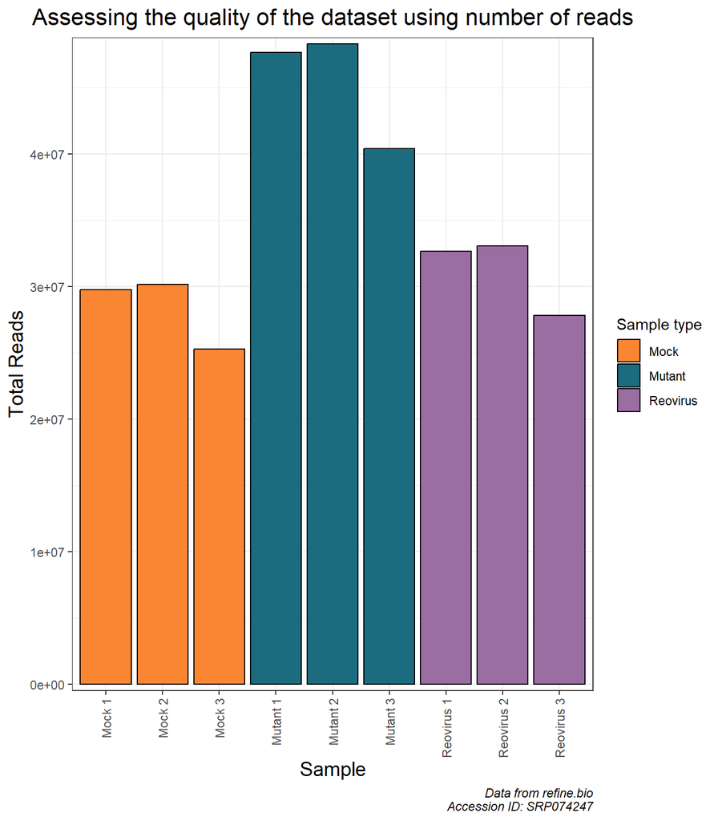

```r
ggplot(data = data_long,
       mapping = aes(x = sample)) +

  geom_col(data = sum_by_sample,
           mapping = aes(y = sum,
                         fill = treatment),
           color = 'black') +

  labs(x = 'Sample',
       y = 'Total Reads',
       title = 'Assessing the quality of the dataset using number of reads',
       caption = 'Data from refine.bio\nAccession ID: SRP074247',
       fill = 'Sample type') +

  theme(plot.title = element_text(hjust = 0.5,
                                  size = 16),
        axis.text.x = element_text(angle = 90,
                                   vjust = 0.5,
                                   hjust = 1),
        axis.title.y = element_text(size = 14),
        axis.title.x = element_text(size = 14),
        legend.position = 'right',
        plot.caption = element_text(face = 'italic')) +

  scale_fill_manual(values = colors) +

  scale_y_continuous(expand = c(0.01, 0))
```

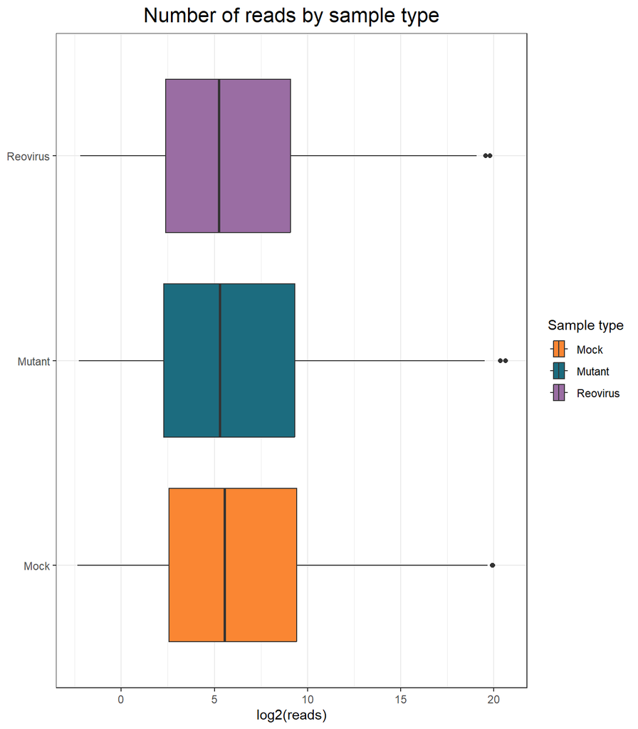

```r
ggplot(data = sum_by_sample |> group_by(treatment) |> summarize('sum' = sum(sum)),
       mapping = aes(x = sum,
                     y = treatment,
                     fill = treatment)) +

  geom_boxplot(data = data_long |> group_by(reads),
               mapping = aes(x = log2(reads))) +


  scale_fill_manual(values = colors) +

  labs(title = 'Number of reads by sample type',
       x = 'log2(reads)',
       y = NULL,
       fill = 'Sample type') +

  theme(plot.title = element_text(hjust = 0.5,
                                  size = 16))
```

```r
# TODO YOU CANT DO A T TEST WITH MORE THAN TWO LEVELS SO WE WILL COME BACK TO THIS
```

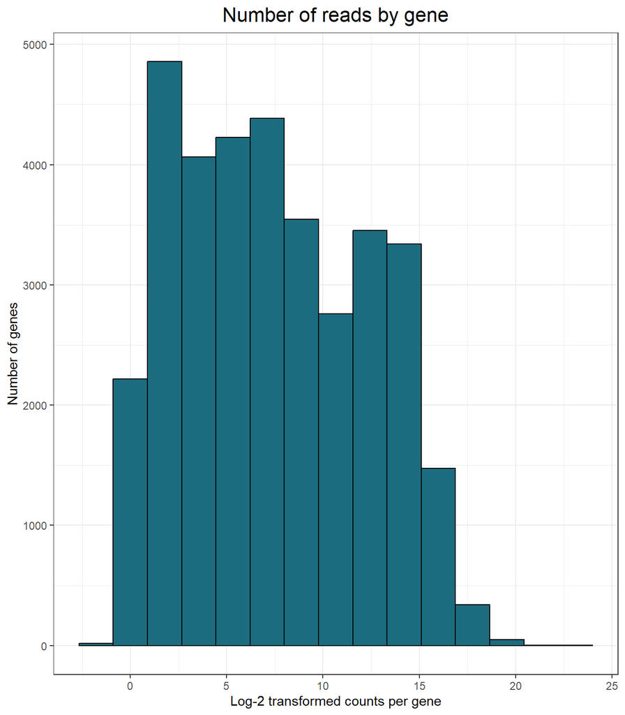

```r
sum_by_gene <-
  data_long |>
  group_by(gene) |>
  summarize('sum' = sum(reads)) |>
  ungroup()

ggplot(data = sum_by_gene,
       mapping = aes(x = log2(sum))) +

  geom_histogram(bins = 15,
                 color = 'black',
                 fill = '#1C6C7F') +

  labs(x = 'Log-2 transformed counts per gene',
       y = 'Number of genes',
       title = 'Number of reads by gene') +

   theme(plot.title = element_text(hjust = 0.5,
                                  size = 16))
```

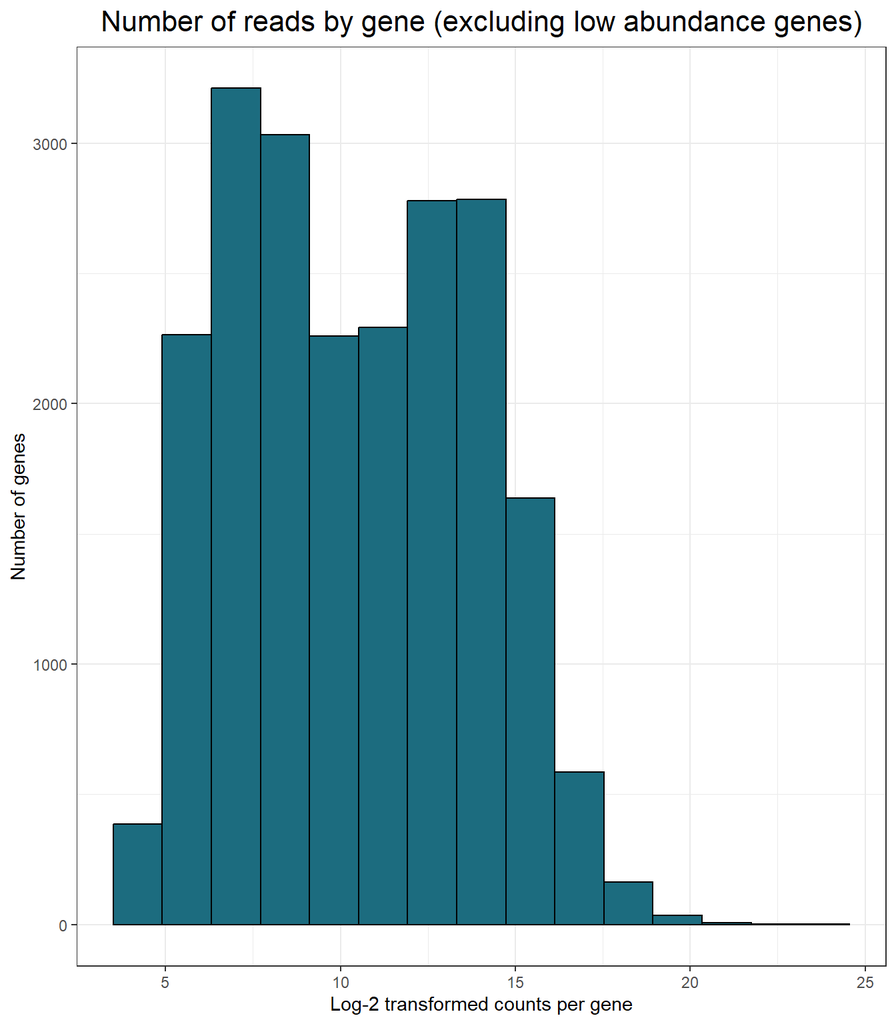

```r
#high_abundance_genes <-
  #data |>
  #filter_if(is.numeric, all_vars((.) != 0))
  #filter(if_any(-gene, ~ !.x  %in% 0)) # why isn't it getting rid of some of the rows with zero

high_abundance_genes <-
  data_long |>
  pivot_wider(names_from = gene,
              values_from = reads) |>
  select(where(~ all(. != 0)))

high_abundance_long <-
  high_abundance_genes |>
  pivot_longer(cols = -c(sample, treatment, replicate),
               names_to = 'gene',
               values_to = 'reads')

high_abundance_sum <-
  high_abundance_long |>
  group_by(gene) |>
  summarize('sum' = sum(reads)) |>
  ungroup()

ggplot(data = high_abundance_sum,
       mapping = aes(x = log2(sum))) +

  geom_histogram(bins = 15,
                 color = 'black',
                 fill = '#1C6C7F') +

  labs(x = 'Log-2 transformed counts per gene',
       y = 'Number of genes',
       title = 'Number of reads by gene (excluding low abundance genes)') +

   theme(plot.title = element_text(hjust = 0.5,
                                  size = 16))
```

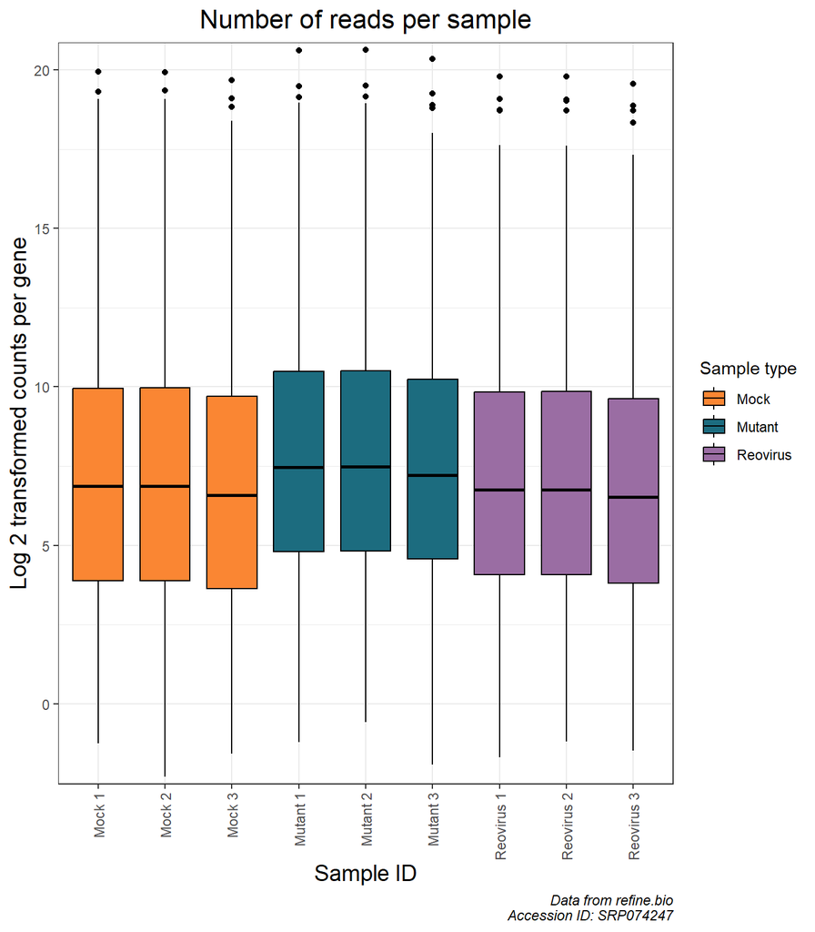

```r
ggplot(data = high_abundance_long,
       mapping = aes(x = sample)) +

  geom_boxplot(mapping = aes(y = log2(reads),
                             fill = treatment),
              color = 'black') +

  labs(x = 'Sample ID',
       y = 'Log 2 transformed counts per gene',
       title = 'Number of reads per sample',
       caption = 'Data from refine.bio\nAccession ID: SRP074247',
       fill = 'Sample type') +

  theme(plot.title = element_text(hjust = 0.5,
                                  size = 16),
        axis.text.x = element_text(angle = 90,
                                   vjust = 0.5,
                                   hjust = 1),
        axis.title.y = element_text(size = 14),
        axis.title.x = element_text(size = 14),
        legend.position = 'right',
        plot.caption = element_text(face = 'italic')) +

  scale_fill_manual(values = colors) +

  scale_y_continuous(expand = c(0.01, 0))
```

```r
sample_names <- c('Mock 1', 'Mock 2', 'Mock 3', 'Mutant 1', 'Mutant 2', 'Mutant 3', 'Reovirus 1', 'Reovirus 2', 'Reovirus 3')
```

```r
high_abundance_log2 <-
  high_abundance_long |>
  mutate(reads = log2(reads)) |>
  pivot_wider(names_from = gene,
              values_from = reads) |>
  select(-c(treatment, replicate))

data_dist <- dist(high_abundance_log2, method = "euclidean")
```

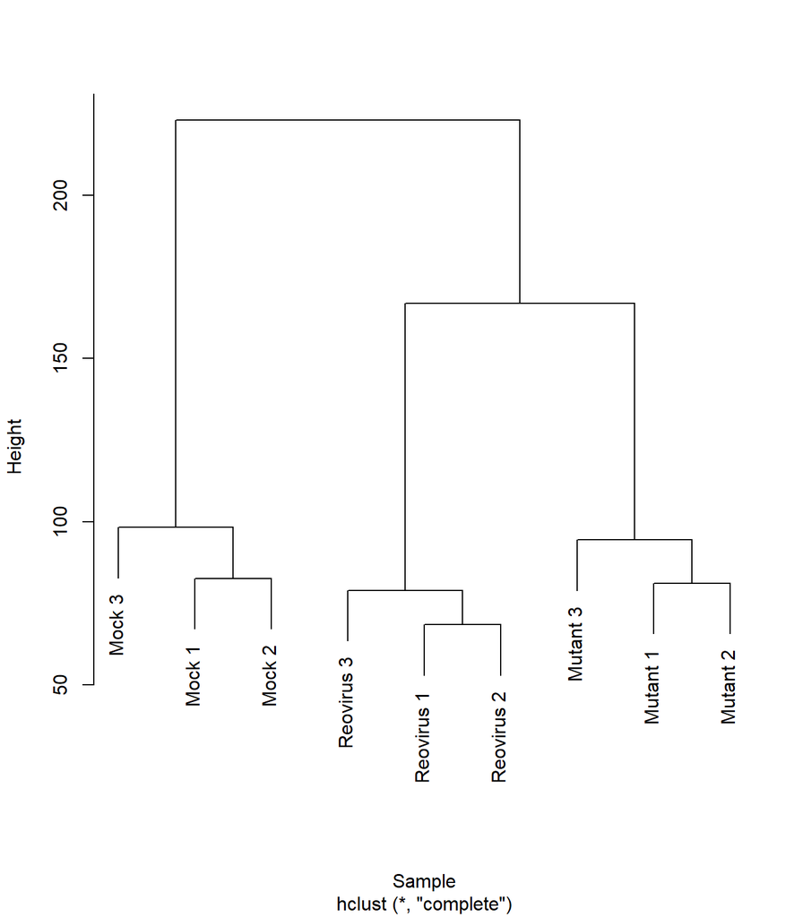

```r
data_dist <- dist_setNames(data_dist, c('Mock 1', 'Mock 2', 'Mock 3', 'Mutant 1', 'Mutant 2', 'Mutant 3', 'Reovirus 1', 'Reovirus 2', 'Reovirus 3'))


plot(hclust(data_dist, method = "complete"), xlab = "Sample", main = NULL)
```

```r
sample_medians <- as.numeric(apply(t(high_abundance_log2), 2, median))

grand_median <- mean(sample_medians)

correction_factors <- grand_median - sample_medians

normalizing <- data.frame(sample_names, correction_factors)

normalizing
```

[output not shown]